# Homework 8:Survival Analysis

```r
data<-read.csv("pneumon.csv")
summary(data)
```

```
##     chldage           mthage          urban           alcohol
##  Min.   : 0.500   Min.   :14.00   Min.   :0.0000   Min.   :0.0000
##  1st Qu.: 8.000   1st Qu.:20.00   1st Qu.:1.0000   1st Qu.:0.0000
##  Median :12.000   Median :22.00   Median :1.0000   Median :0.0000
##  Mean   : 9.845   Mean   :21.64   Mean   :0.7605   Mean   :0.3576
##  3rd Qu.:12.000   3rd Qu.:23.00   3rd Qu.:1.0000   3rd Qu.:1.0000
##  Max.   :12.000   Max.   :29.00   Max.   :1.0000   Max.   :1.0000
##      smoke            region        poverty          bweight
##  Min.   :0.0000   Min.   :1.00   Min.   :0.0000   Min.   :0.0000
##  1st Qu.:0.0000   1st Qu.:2.00   1st Qu.:1.0000   1st Qu.:0.0000
##  Median :0.0000   Median :3.00   Median :1.0000   Median :0.0000
##  Mean   :0.3415   Mean   :2.65   Mean   :0.9222   Mean   :0.3597
##  3rd Qu.:1.0000   3rd Qu.:3.00   3rd Qu.:1.0000   3rd Qu.:1.0000
##  Max.   :1.0000   Max.   :4.00   Max.   :1.0000   Max.   :1.0000
##       race        education         nsibs            wmonth
##  Min.   :1.00   Min.   : 0.00   Min.   :0.0000   Min.   : 0.000
##  1st Qu.:1.00   1st Qu.:10.00   1st Qu.:0.0000   1st Qu.: 0.000
##  Median :1.00   Median :12.00   Median :0.0000   Median : 0.000
##  Mean   :1.61   Mean   :11.44   Mean   :0.6775   Mean   : 1.926
##  3rd Qu.:2.00   3rd Qu.:12.00   3rd Qu.:1.0000   3rd Qu.: 2.000
##  Max.   :3.00   Max.   :19.00   Max.   :6.0000   Max.   :28.000
##     sfmonth           agepn
##  Min.   : 0.000   Min.   : 0.000
##  1st Qu.: 0.000   1st Qu.: 3.000
##  Median : 0.000   Median :10.000
##  Mean   : 1.121   Mean   : 7.865
##  3rd Qu.: 1.000   3rd Qu.:12.000
##  Max.   :18.000   Max.   :12.000
```

```r
str(data)
```

```
## 'data.frame':    3470 obs. of  14 variables:
##  $ chldage  : num  12 12 3 2 4 12 7 3 7 12 ...
##  $ mthage   : int  22 20 24 22 21 20 24 24 26 21 ...
##  $ urban    : int  1 1 1 1 1 1 1 1 1 1 ...
##  $ alcohol  : int  0 1 1 1 1 0 0 1 1 1 ...
##  $ smoke    : int  0 0 0 1 1 0 0 0 1 0 ...
##  $ region   : int  1 1 1 1 1 1 1 1 1 1 ...
##  $ poverty  : int  1 1 1 1 1 1 1 1 1 1 ...
##  $ bweight  : int  1 0 0 0 1 0 0 0 0 0 ...
##  $ race     : int  1 1 1 1 1 1 1 1 1 1 ...
##  $ education: int  10 12 12 9 12 12 12 14 12 12 ...
##  $ nsibs    : int  1 1 2 0 0 0 1 0 0 0 ...
##  $ wmonth   : int  1 2 1 0 0 0 0 4 1 3 ...
##  $ sfmonth  : int  1 2 0 0 0 0 0 2 1 2 ...
##  $ agepn    : int  1 12 3 2 4 12 7 3 6 12 ...
```

```r
library(car)
pneumon<-recode(data$chldage,"1:11=1;else=0")
data1<-data.frame(data,pneumon=pneumon)
data1$nsibs<-recode(data1$nsibs,"1=1;2=2;else=3")
data1$wmonth<-recode(data1$wmonth,"1=1;2=2;3=3;4:6=4;else=5")
data1$urban<-as.factor(data1$urban)
data1$alcohol<-as.factor(data1$alcohol)
data1$smoke<-as.factor(data1$smoke)
data1$region<-as.factor(data1$region)
data1$poverty<-as.factor(data1$poverty)
data1$bweight<-as.factor(data1$bweight)
data1$race<-as.factor(data1$race)
data1$agepn<-as.numeric(data1$agepn)
data1$sfmonth<-as.numeric(data1$sfmonth)
```

Now we can see that I have new status variable in the data(pneumon) which is 1 for those children who had pneumonia at age less than 12 months and 0 who didn’t get pneumonia in that period.

```r
str(data1)
```

```
## 'data.frame':    3470 obs. of  15 variables:
##  $ chldage  : num  12 12 3 2 4 12 7 3 7 12 ...
##  $ mthage   : int  22 20 24 22 21 20 24 24 26 21 ...
##  $ urban    : Factor w/ 2 levels "0","1": 2 2 2 2 2 2 2 2 2 2 ...
##  $ alcohol  : Factor w/ 2 levels "0","1": 1 2 2 2 2 1 1 2 2 2 ...
##  $ smoke    : Factor w/ 2 levels "0","1": 1 1 1 2 2 1 1 1 2 1 ...
##  $ region   : Factor w/ 4 levels "1","2","3","4": 1 1 1 1 1 1 1 1 1 1 ...
##  $ poverty  : Factor w/ 2 levels "0","1": 2 2 2 2 2 2 2 2 2 2 ...
##  $ bweight  : Factor w/ 2 levels "0","1": 2 1 1 1 2 1 1 1 1 1 ...
##  $ race     : Factor w/ 3 levels "1","2","3": 1 1 1 1 1 1 1 1 1 1 ...
##  $ education: int  10 12 12 9 12 12 12 14 12 12 ...
##  $ nsibs    : num  1 1 2 3 3 3 1 3 3 3 ...
##  $ wmonth   : num  1 2 1 5 5 5 5 4 1 3 ...
##  $ sfmonth  : num  1 2 0 0 0 0 0 2 1 2 ...
##  $ agepn    : num  1 12 3 2 4 12 7 3 6 12 ...
##  $ pneumon  : num  0 0 1 1 1 0 1 1 1 0 ...
```

So, my event variable is pneumon, and time variable is chldage.

```r
library(survival)
sobject<-Surv(data1$chldage,data1$pneumon)
```

```r
km_sib<-survfit(sobject~nsibs,data=data1)
```

```r
summary(km_sib)
```

```
## Call: survfit(formula = sobject ~ nsibs, data = data1)
##
##                 nsibs=1
##  time n.risk n.event survival std.err lower 95% CI upper 95% CI
##     1   1123      46    0.959 0.00591        0.948        0.971
##     2   1077      26    0.936 0.00731        0.922        0.950
##     3   1051      27    0.912 0.00846        0.895        0.929
##     4   1024      40    0.876 0.00983        0.857        0.896
##     5    984      39    0.841 0.01090        0.820        0.863
##     6    945      34    0.811 0.01168        0.789        0.834
##     7    911      31    0.784 0.01229        0.760        0.808
##     8    880      35    0.752 0.01288        0.728        0.778
##     9    845      37    0.720 0.01341        0.694        0.746
##    10    808      31    0.692 0.01378        0.665        0.719
##    11    777      31    0.664 0.01409        0.637        0.692
```

[output cut: 28 more lines]

The summary shows that during the time survival chances are decreasing.

Here are the survival probabilities.

```r
km_sib$surv
```

```
##  [1] 1.0000000 0.9590383 0.9358860 0.9118433 0.8762244 0.8414960 0.8112199
##  [8] 0.7836153 0.7524488 0.7195013 0.6918967 0.6642921 0.6642921 1.0000000
## [15] 0.9679144 0.9037433 0.8636364 0.8342246 0.7994652 0.7620321 0.7245989
## [22] 0.6925134 0.6524064 0.6336898 0.6149733 0.6149733 1.0000000 0.9756485
## [29] 0.9502382 0.9221810 0.8983589 0.8660667 0.8380095 0.8104817 0.7840127
## [36] 0.7644256 0.7432504 0.7252515 0.7252515
```

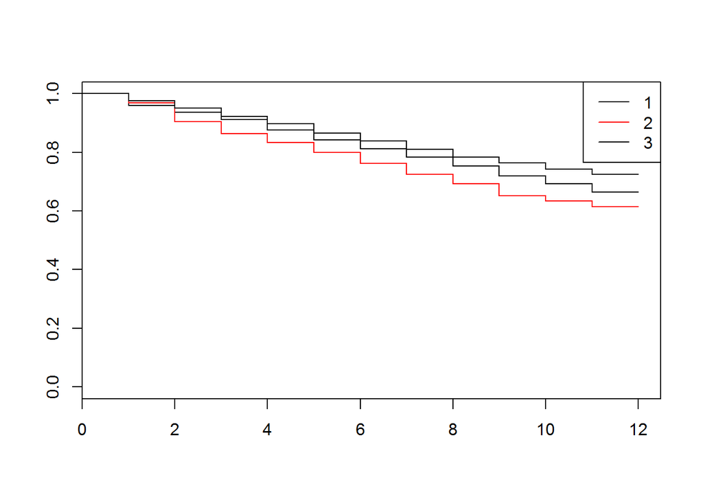

```r
plot(km_sib, conf.int = F, col=1:2, ylim=c(0,1))
legend("topright", legend=unique(data1$nsibs), col=1:2, lty=1)
```

As the graph shows children who have 1 or 3 siblings have more chances to survive when the time is increasing compared with those who have 2 siblings. The same can be seen from the hazard function, and hypothesis testing shows that this difference is significant.

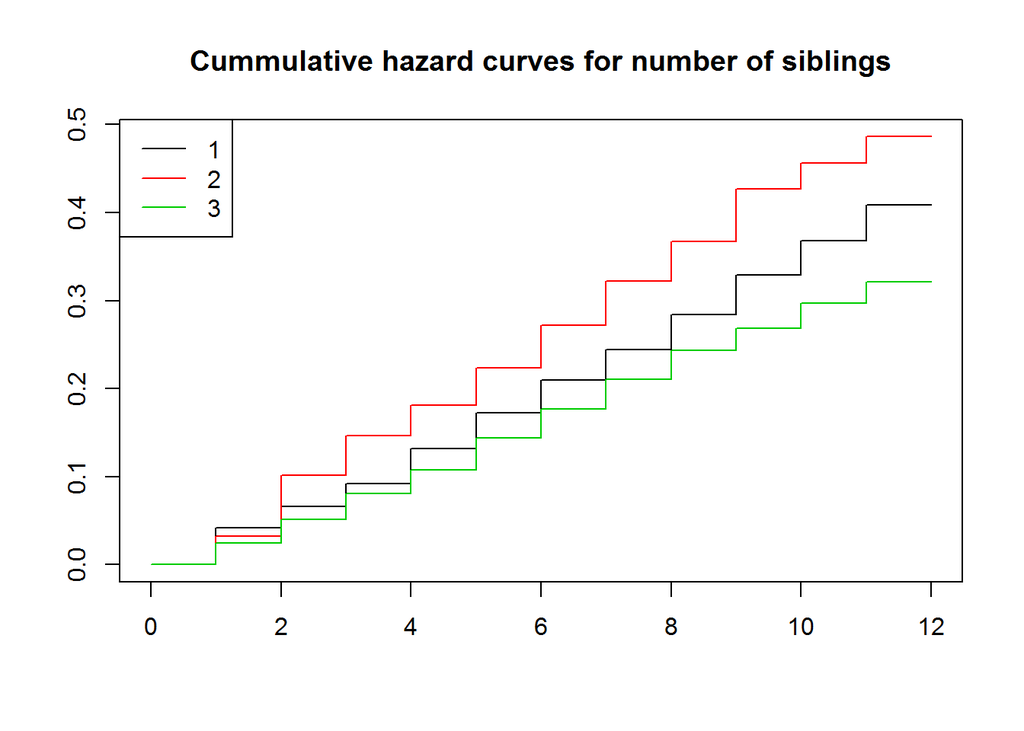

```r
plot(survfit(sobject~nsibs, data=data1), conf.int = F, col=1:5,
     main="Cummulative hazard curves for number of siblings", fun="cumhaz")
legend("topleft", legend=unique(data1$nsibs), col=1:5,lty=1)
```

```r
survdiff(sobject~nsibs, data=data1)
```

```
## Call:
## survdiff(formula = sobject ~ nsibs, data = data1)
##
##            N Observed Expected (O-E)^2/E (O-E)^2/V
## nsibs=1 1156      377      341      3.75      5.77
## nsibs=2  383      144      108     11.97     13.81
## nsibs=3 1931      519      591      8.71     20.85
##
##  Chisq= 25.3  on 2 degrees of freedom, p= 3.26e-06
```

We can reject the “H0: The survival curves are not different” hypothesis as p-value is less than 0.05, so there is significant difference between survival curves for different numbers of siblings(1,2,3).

# Q2:Test the hypothesis of differences

```r
survdiff(sobject~urban, data=data1)
```

```
## Call:
## survdiff(formula = sobject ~ urban, data = data1)
##
##            N Observed Expected (O-E)^2/E (O-E)^2/V
## urban=0  831      258      246     0.621     0.841
## urban=1 2639      782      794     0.192     0.841
##
##  Chisq= 0.8  on 1 degrees of freedom, p= 0.359
```

As we can see survival for urban and not urban populations is not significantly different, as p-value is more than 0.05 and we failed to reject “H0: The survival curves are not different”.

```r
survdiff(sobject~alcohol, data=data1)
```

```
## Call:
## survdiff(formula = sobject ~ alcohol, data = data1)
##
##              N Observed Expected (O-E)^2/E (O-E)^2/V
## alcohol=0 2229      660      672     0.226     0.661
## alcohol=1 1241      380      368     0.414     0.661
##
##  Chisq= 0.7  on 1 degrees of freedom, p= 0.416
```

Again, children’s survival is not significantly different for parents who use alcohol compared with not users. We don’t reject “H0: The survival curves are not different for alcohol users and not users”.

```r
survdiff(sobject~smoke, data=data1)
```

```
## Call:
## survdiff(formula = sobject ~ smoke, data = data1)
##
##            N Observed Expected (O-E)^2/E (O-E)^2/V
## smoke=0 2285      665      687     0.693      2.11
## smoke=1 1185      375      353     1.349      2.11
##
##  Chisq= 2.1  on 1 degrees of freedom, p= 0.146
```

We failed to reject “H0: The survival curves are not different”, which means that children’s survival curve whose mothers smoked during the pregnancy isn’t significantly different from the children’s survival curve whose mothers didn’t smoke.

```r
survdiff(sobject~region, data=data1)
```

```
## Call:
## survdiff(formula = sobject ~ region, data = data1)
##
##             N Observed Expected (O-E)^2/E (O-E)^2/V
## region=1  517      163      155   0.38817    0.4717
## region=2  868      261      257   0.05747    0.0789
## region=3 1396      406      419   0.40369    0.6989
## region=4  689      210      209   0.00938    0.0121
##
##  Chisq= 0.9  on 3 degrees of freedom, p= 0.828
```

Survival curves for children from different regions is not different at 5% significance level. This means that we cannot reject “H0: The survival curves are not different” hypothesis.

```r
survdiff(sobject~poverty, data=data1)
```

```
## Call:
## survdiff(formula = sobject ~ poverty, data = data1)
##
##              N Observed Expected (O-E)^2/E (O-E)^2/V
## poverty=0  270       89     79.5    1.1286      1.26
## poverty=1 3200      951    960.5    0.0934      1.26
##
##  Chisq= 1.3  on 1 degrees of freedom, p= 0.261
```

The survival curves for the children with poor parents and not poor is not significantly different.

```r
survdiff(sobject~bweight, data=data1)
```

```
## Call:
## survdiff(formula = sobject ~ bweight, data = data1)
##
##              N Observed Expected (O-E)^2/E (O-E)^2/V
## bweight=0 2222      665      665  7.62e-05  0.000218
## bweight=1 1248      375      375  1.35e-04  0.000218
##
##  Chisq= 0  on 1 degrees of freedom, p= 0.988
```

Survival curves for children with normal and not normal birth weight arw not different. We don’t reject H0.

```r
survdiff(sobject~race, data=data1)
```

```
## Call:
## survdiff(formula = sobject ~ race, data = data1)
##
##           N Observed Expected (O-E)^2/E (O-E)^2/V
## race=1 1933      597      576     0.783     1.813
## race=2  957      260      290     3.175     4.553
## race=3  580      183      174     0.480     0.595
##
##  Chisq= 4.6  on 2 degrees of freedom, p= 0.101
```

Again, there is no significant difference in survival curves for children from different race groups.

Moreover, I want to run regression model to see how some of these variables impact survival and hazard time.

Also, I want to see survival curve for children whose mothers smoked.

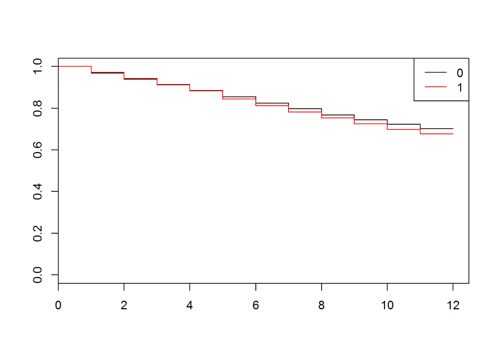

```r
km_smoke<-survfit(sobject~smoke,data=data1)
plot(km_smoke, conf.int = F, col=1:2, ylim=c(0,1))
legend("topright", legend=unique(data1$smoke), col=1:2, lty=1)
```

We got similar results to hypothesis testing. The difference between children whose mothers smoked and children whose moders didn’t smoke is not significant.

In addition, to see joint impact of some variables on having pneumonia, I have conduct regression analysis.

```r
reg<-survreg(sobject~race+smoke+poverty+bweight+nsibs, data=data1, dist="exponential")
summary(reg)
```

```
##
## Call:
## survreg(formula = sobject ~ race + smoke + poverty + bweight +
##     nsibs, data = data1, dist = "exponential")
##                Value Std. Error       z         p
## (Intercept)  3.11386     0.1388 22.4397 1.61e-111
## race2        0.14912     0.0782  1.9069  5.65e-02
## race3       -0.02745     0.0872 -0.3147  7.53e-01
## smoke1      -0.06876     0.0670 -1.0266  3.05e-01
## poverty1     0.11409     0.1117  1.0215  3.07e-01
## bweight1    -0.00439     0.0678 -0.0647  9.48e-01
## nsibs        0.12060     0.0333  3.6264  2.87e-04
##
## Scale fixed at 1
##
## Exponential distribution
## Loglik(model)= -4661.2   Loglik(intercept only)= -4671.6
##  Chisq= 20.72 on 6 degrees of freedom, p= 0.0021
## Number of Newton-Raphson Iterations: 5
## n= 3470
```

```r
exp(reg$coefficients)
```

```
## (Intercept)       race2       race3      smoke1    poverty1    bweight1
##  22.5078033   1.1608181   0.9729207   0.9335538   1.1208481   0.9956242
##       nsibs
##   1.1281756
```

# Q3:Cox regression model

.

```r
surv_cox<-coxph(sobject~nsibs+wmonth+mthage+race+poverty+bweight+smoke,data=data1)
summary(surv_cox)
```

```
## Call:
## coxph(formula = sobject ~ nsibs + wmonth + mthage + race + poverty +
##     bweight + smoke, data = data1)
##
##   n= 3470, number of events= 1040
##
##               coef exp(coef)  se(coef)      z Pr(>|z|)
## nsibs    -0.029545  0.970887  0.034437 -0.858  0.39093
## wmonth   -0.057962  0.943686  0.021466 -2.700  0.00693 **
## mthage    0.156851  1.169821  0.012114 12.948  < 2e-16 ***
## race2    -0.004159  0.995849  0.079964 -0.052  0.95852
## race3     0.099717  1.104859  0.087579  1.139  0.25487
## poverty1 -0.162167  0.850299  0.111905 -1.449  0.14730
## bweight1  0.165263  1.179704  0.069214  2.388  0.01695 *
## smoke1    0.112918  1.119540  0.067029  1.685  0.09206 .
## ---
## Signif. codes:  0 '***' 0.001 '**' 0.01 '*' 0.05 '.' 0.1 ' ' 1
##
##          exp(coef) exp(-coef) lower .95 upper .95
## nsibs       0.9709     1.0300    0.9075    1.0387
## wmonth      0.9437     1.0597    0.9048    0.9842
## mthage      1.1698     0.8548    1.1424    1.1979
## race2       0.9958     1.0042    0.8514    1.1648
## race3       1.1049     0.9051    0.9306    1.3118
## poverty1    0.8503     1.1761    0.6828    1.0588
## bweight1    1.1797     0.8477    1.0300    1.3511
## smoke1      1.1195     0.8932    0.9817    1.2767
##
## Concordance= 0.621  (se = 0.009 )
## Rsquare= 0.056   (max possible= 0.992 )
## Likelihood ratio test= 199.5  on 8 df,   p=0
## Wald test            = 198.6  on 8 df,   p=0
## Score (logrank) test = 201.6  on 8 df,   p=0
```

# Q4:Proportional hazard

We are going to check the following hypothesis: H0: Hazards are proportional H1: Hazards are not proportional

```r
TZ<-cox.zph(surv_cox, global=T, transform="rank")
TZ
```

```
##               rho   chisq      p
## nsibs    -0.00893  0.0831 0.7732
## wmonth    0.04979  2.6567 0.1031
## mthage    0.07053  4.9296 0.0264
## race2     0.00357  0.0135 0.9074
## race3     0.04577  2.1861 0.1393
## poverty1 -0.01048  0.1168 0.7326
## bweight1 -0.02899  0.8689 0.3513
## smoke1    0.03503  1.2249 0.2684
## GLOBAL         NA 11.3612 0.1821
```

As we can see the proportional hazard assumption was violated only in case of mthage(age of mother) when the H0 is rejected. In addition, the overall hazard of the model is more than 0.05, which means we don’t reject null hypothesis.

# Q5: Summary